# Null Hypothesis Testing

Klinkenberg

13 sep 2018

# Null Hypothesis Significance Testing

Neyman-Pearson Paradigm

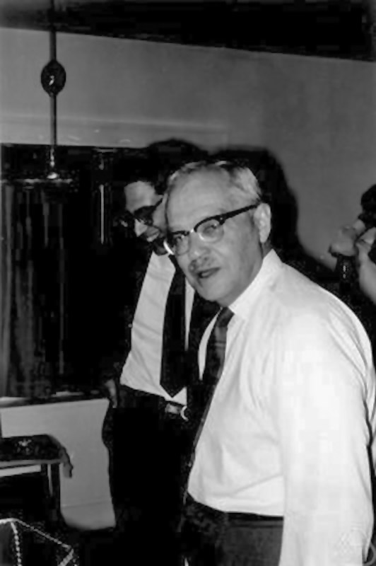

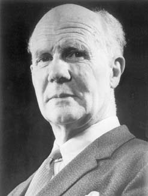

## $H_0$ and $H_A$

$H_0$

- Skeptical point of view
- No effect
- No preference
- No Correlation
- No difference

$H_A$

- Refute Skepticism
- Effect
- Preference
- Correlation
- Difference

## Frequentist probability

- Objective Probability
- Relative frequency in the long run

## Standard Error

> 95% confidence interval

$$SE = \frac{\text{Standard deviation}}{\text{Square root of sample size}} = \frac{s}{\sqrt{n}}$$

- Lowerbound = $\bar{x} - 1.96 \times SE$
- Upperbound = $\bar{x} + 1.96 \times SE$

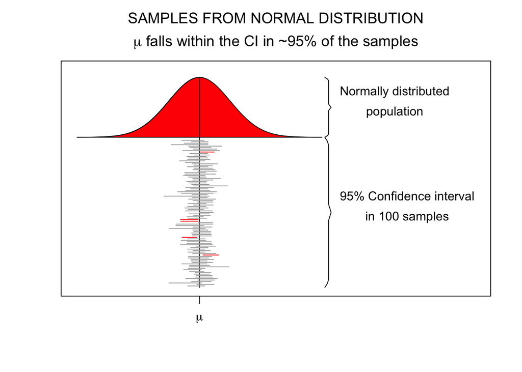

## Binomial $H_0$ distribution

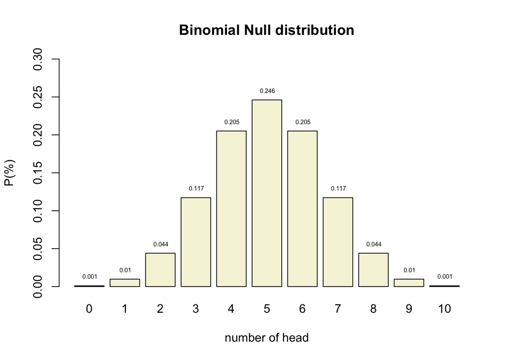

```r
n = 10   # Sample size
k = 0:n  # Discrete probability space
p = .5   # Probability of head

munt = 0:1

permutations = factorial(n) / ( factorial(k) * factorial(n-k) )
# permutations

p_k  = p^k * (1-p)^(n-k)  # Probability of single event
p_kp = p_k * permutations # Probability of event times
                          # the occurrence of that event

title = "Binomial Null distribution"

# col=c(rep("red",2),rep("beige",7),rep("red",2))

barplot( p_kp,
         main=title,
         names.arg=0:10,
         xlab="number of head",
         ylab="P(%)",
         col='beige',
         ylim=c(0,.3) )

# abline(v = c(2.5,10.9), lty=2, col='red')

text(.6:10.6*1.2,p_kp,round(p_kp,3),pos=3,cex=.5)
```

## Binomial $H_A$ distribution

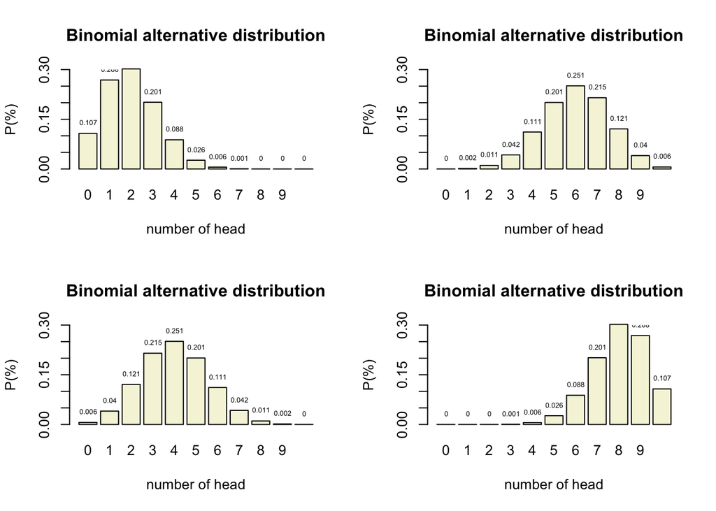

## Decision table

|  | $H_0$ = True | $H_0$ = False |
| --- | --- | --- |
| Decide to reject $H_0$ | Type I error Alpha $\alpha$ | Correct True positive = Power |
| Decide not to reject $H_0$ | Correct True negative | Type II error Beta $\beta$ |

## Alpha $\alpha$

- Incorrectly reject $H_0$
- Type I error
- False Positive
- Criteria often 5%
- Distribution depends on sample size

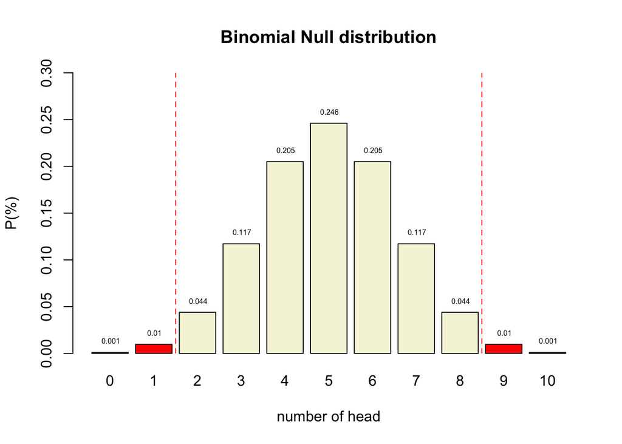

## Power

- Correctly reject $H_0$
- True positive
- Power equal to: 1 - Beta
  - Beta is Type II error
- Criteria often 80%
- Depends on sample size

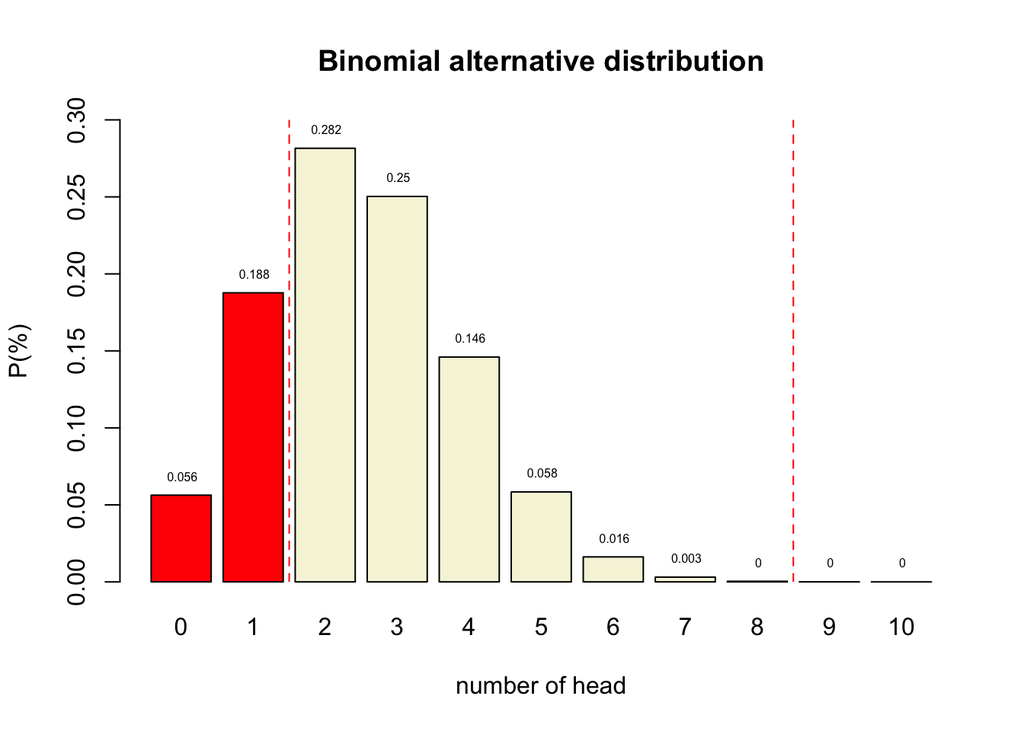

## Post-Hoc Power

> The power of a test assuming a population effect size equal to the observed effect size in the current sample.

Source: [O’Keefe (2007)](http://www.dokeefe.net/pub/okeefe07cmm-posthoc.pdf)

## Effect size

In statistics, an effect size is a quantitative measure of the strength of a phenomenon. Examples of effect sizes are the correlation between two variables, the regression coefficient in a regression, the mean difference and standardised differences.

For each type of effect size, a larger absolute value always indicates a stronger effect. Effect sizes complement statistical hypothesis testing, and play an important role in power analyses, sample size planning, and in meta-analyses.

Source: [WIKIPEDIA](https://en.wikipedia.org/wiki/Effect_size)

## Effect size

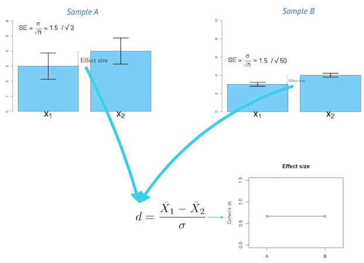

## 1 - alpha

- Correctly accept $H_0$
- True negative

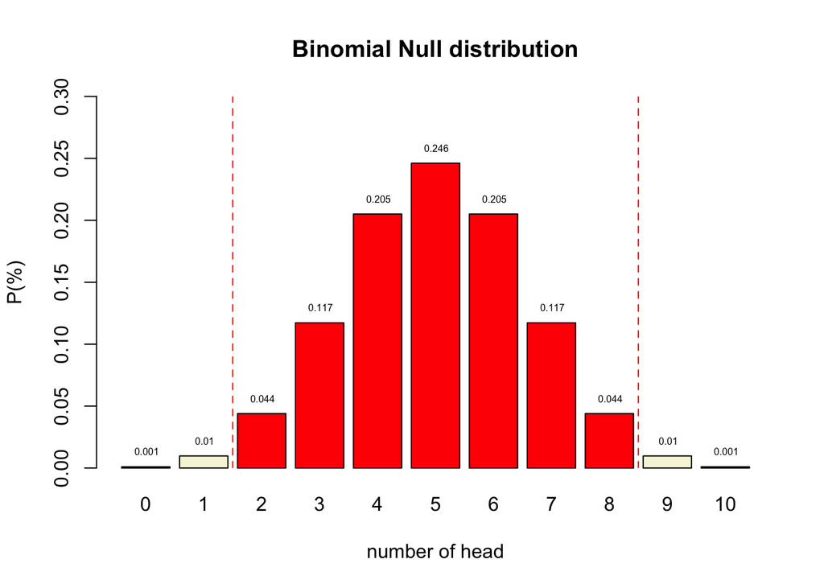

## Beta

- Incorrectly accept $H_0$
- Type II error
- False Negative
- Criteria often 20%
- Distribution depends on sample size

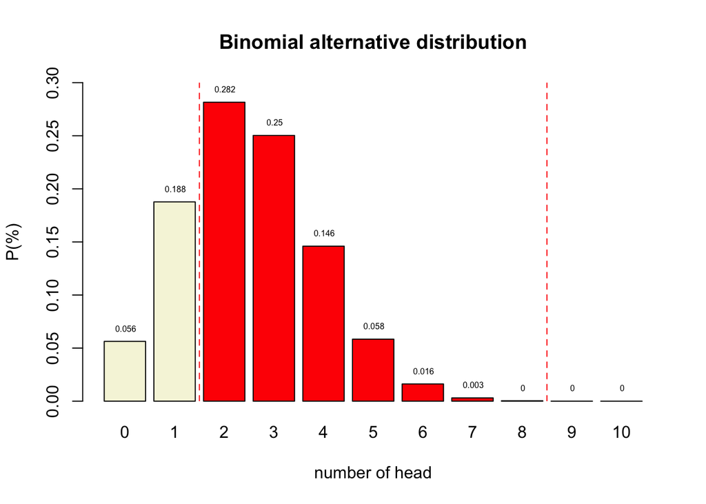

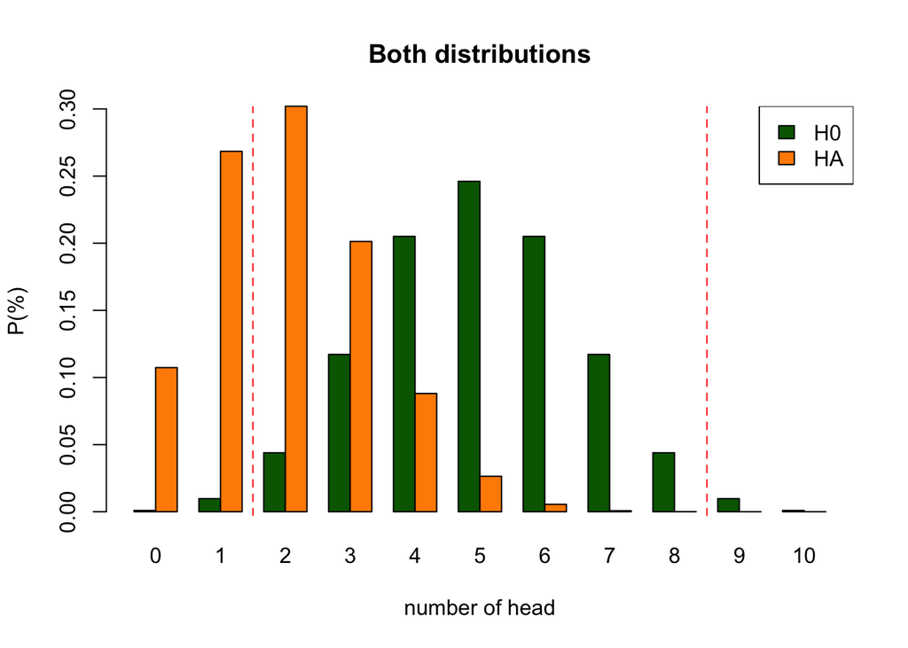

## P-value

> Conditional probability of the found test statistic or more extreme assuming the null hypothesis is true.

Reject $H_0$ when:

- $p$-value <= $alpha$

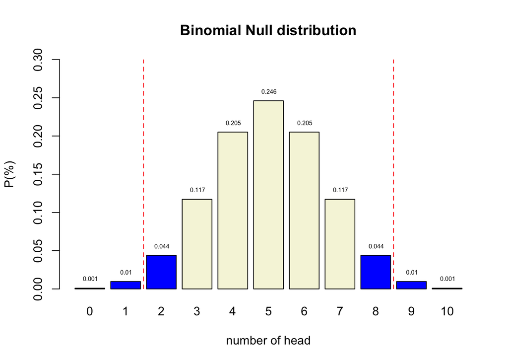

## Test statistics

Some common test statistics

- Number of heads
- Sum of dice
- Difference
- $t$-statistic
- $F$-statistic
- $\chi^2$-statistic
- etc…

## Decision Table

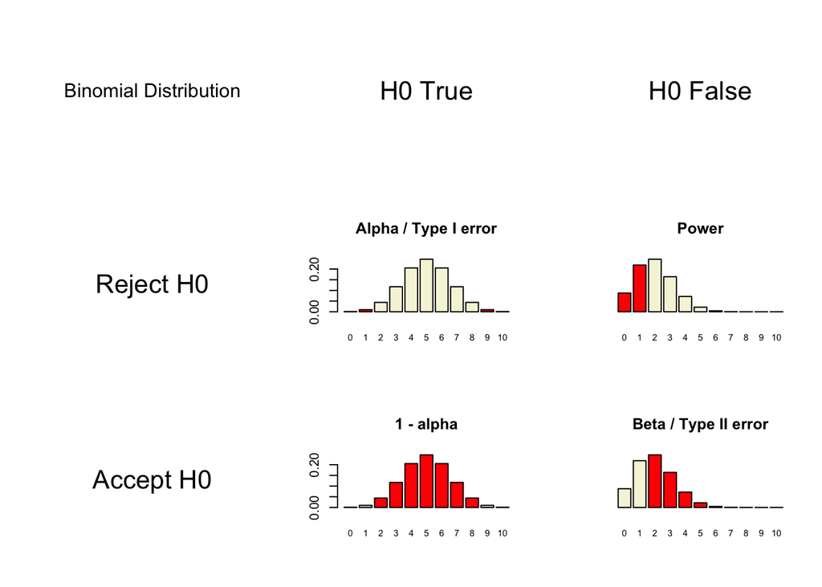

```r
N     = 10  # Sample size
H0    = .5  # Probability of head under H0 50/50
HA    = .2  # Aternative expected value
alpha = .05 # Selected type I error

# Color areas red for selected alpha
area <- dbinom(0:N, N, H0) < alpha/2

col = rep("beige", N+1)
col[area] = "red"

col2 = rep("red", N+1)
col2[area] = "beige"

# Delete # to not color the plots
# col = col2  = "beige"

layout(matrix(1:9,3,3, byrow=T))

plot.new()
text(0.5,0.5,"Binomial Distribution",cex=1.5)
# text(0.5,0.1,paste("N:",N),cex=1.5)

plot.new()
text(0.5,0.5,"H0 True",cex=2)

plot.new()
text(0.5,0.5,"H0 False",cex=2)

plot.new()
text(0.5,0.5,"Reject H0",cex=2)

barplot(dbinom(0:N,N, H0),
        col  = col,
        # yaxt = 'n',
        main = 'Alpha / Type I error',
        names.arg = 0:N,
        cex.names = 0.7)

barplot(dbinom(0:N,N, HA),
        col  = col,
        yaxt = 'n',
        main = 'Power',
        names.arg = 0:N,
        cex.names = 0.7)

plot.new()
text(0.5,0.5,"Accept H0",cex=2)

barplot(dbinom(0:N,N, H0),
        col  = col2,
        # yaxt = 'n',
        main = '1 - alpha',
        names.arg = 0:N,
        cex.names = 0.7)

barplot(dbinom(0:N,N, HA),
        col  = col2,
        yaxt = 'n',
        main = 'Beta / Type II error',
        names.arg = 0:N,
        cex.names = 0.7)
```

## Reasoning Scheme

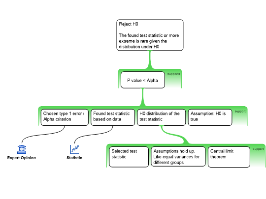

NHST Reasoning Scheme

## R<-PSYCHOLOGIST

[interactive chart not shown]

Source: [Kristoffer Magnusson](http://rpsychologist.com/d3/NHST/)

# End

- [@shklinkenberg](https://twitter.com/shklinkenberg)
- [Klinkenberg](https://www.linkedin.com/in/sharonklinkenberg/)
- ln.AvU@grebneknilK.S
- ShKlinkenberg